# Advanced Project: Long Run

## Implementing the Solow-Romer Model

```python
import numpy as np
import pandas as pd
import matplotlib.pyplot as plt
import altair as alt
```

### Q1) Calibration

A vital component of every Macroeconomic model is the "Calibration." To numerically implement a model, we need values for our parameters or calibrate our model. For example, there are two parameters in the Solow-Romer model, the growth rate of TFP and the Population growth rate. Calculate the average growth rate of TFP and Population over the last 50 years. Hint: you can't average the yearly growth rates; you have to consider compounding.

Use these data series from FRED: TFP (RTFPNAUSA632NRUG) and Population (LFWA64TTUSM647N). You can do it manually as we have always done, or use an API. Guide [HERE](https://github.com/mortada/fredapi). Help on installation of packages through pip is [Here](https://jakevdp.github.io/blog/2017/12/05/installing-python-packages-from-jupyter/)

Show all your calculations and answers formatted in the correct units up to two decimal places.

## Finding Steady State

The steady-state level of capital is such that

$$ \bar{s}Y^\ast = (z*l+n+\delta)k^\ast. $$

Replacing Output with from th eporduction function we can now get: $$ s(1-l)^{1-\alpha}k^{\ast \alpha} = (z*l+n+\delta)k^\ast $$

We now solve for $k^\ast$ which yields:

$$ k^{\ast} = \left(\frac{s}{zl+n+\delta}\right)^{\frac{1}{1-\alpha}}(1-l) $$

We will now find the steady-state level of production. Using the production function we have

$$ y^{\ast} = (1-l)^{1-\alpha} k^{\ast\alpha} $$

Substituting the solutions for $k^\ast$ into this equation and simplifying we get:

$$ y^{\ast} = (1-l)\left(\frac{s}{zl+n+\delta}\right)^{\frac{\alpha}{1-\alpha}} $$

This equation gives us the solved amoutn of output for the steady state.

```python
#Input Data Sets Needed
Population = pd.read_csv("C:/Users/walbr/Desktop/Intermediate Macro/Advanced Project/Labor.csv",
                   header=0, names=['Date', 'Total Factor Productivity'], index_col = 0)

TFP = pd.read_csv("C:/Users/walbr/Desktop/Intermediate Macro/Advanced Project/TFP.csv",
                   header=0, names=['Date', 'Total Factor Productivity'], index_col = 0)

Data = pd.read_csv("C:/Users/walbr/Desktop/Intermediate Macro/Advanced Project/Both.csv",
                   header=0, names=['date', 'Pop', 'TFP'], encoding='ascii', engine='python')


#Make Dates into datetime form(Will help with Graphs later)
Data['date'] = pd.to_datetime(Data['date'])

#check Data is fomatted corectly to work with
#print(Data.to_markdown())

lg = len(Data)

#Create Percentage Change columns to fit g and n to the data.
n = (Data['Pop'][lg-1]/Data['Pop'][0])**(1/len(Data)) -1
g = (Data['TFP'][lg-1]/Data['TFP'][0])**(1/len(Data)) -1

#Show g & n
print(n)
print(g)
```

```
0.011821202743911963
0.006275183956228281
```

### Q2) Steady State

Now that you have parameters "g" and "n," assume these values for the rest of the parameters: $s=0.1$, $\delta=0.06$, $\alpha=0.33$, $\ell=0.01$. Solve for the value of $k=\frac{K}{AL}$ in the steady-state, $k^*$.

```python
#Assumed values
s = .1 #savings rate
d = 0.06 #depreciation
alpha = 0.33 #Investingrate
l = 0.01 #LaborInReseach
n=n #Found Above Percent Change of population
z = g/l #research productivity

#make k for y_star
k = (s/(z*l+n+d))**(1/(1-alpha))*(1-l)

#make steady state k function
def k_star(s, z, l, n, d, alpha):
    k = (s/(z*l+n+d))**(1/(1-alpha))*(1-l)
    return k

#make steady state output
def y_star(l,k):
    return (1-l)*k


Capital_steady = k_star(s, z, l, n, d, alpha)
Output_steady = y_star(l,k)

print('Capital steady state: ', '{:,.2f}'.format(k_star(s,z,l,n,d,alpha)))
print('Output steady state: ', '{:,.2f}'.format(y_star(l,k)))
```

[output not shown]

### Q3) Implementing Solow-Romer

Suppose that $K_0=1,000$, $L_0=500$, and $A_0=1.7$. Implement the Solow-Romer model in Python using the parameter values from Q2).

**a)** How long does it take the model to reach the steady-state?

```python
#Parameters
s = .1 #savings rate
d = 0.06 #depreciation
alpha = 0.33 #Investingrate
n = n #population growth found earlier
l = 0.01 #LaborInReseach
z = g/l #research productivity


#Starting Levels
K_0 = 1000
L_0 = 500
A_0 = 1.7
Y_0 = ((1-l)**(1-alpha)) *(K_0**(alpha)) *(A_0*L_0)**(1-alpha) #Initial output
I_0 = s*Y_0
C_0 = (1-s)*Y_0
k_s = k_star(s, z, l, n, d, alpha)

#Arrays for While Loop
time = [0]
#Levels
A = np.array([A_0])
L = np.array([L_0])
Y = np.array([Y_0])
K = np.array([K_0])
I = np.array([I_0])
C = np.array([C_0])
#Effiency Units
k = np.array([K_0/(A_0*L_0)])
change_k = np.array([np.nan])
i = 0

epsilon = .01 #How close does it need to get?

while (abs(k[i] - k_s)) > epsilon:
    i += 1
    time = np.append(time, i)

    #Effiency units
    change_k = np.append(change_k,s*((1-l)**(1-alpha))*(k[i-1]**(alpha))-(z*l+n+d)*k[i-1])
    k = np.append(k, k[i-1] + change_k[i])

    #Levels
    L = np.append(L, L[i-1]*(1+n)) #Growth Rate of US
    A = np.append(A, A[i-1]*(1+z*l))
    K = np.append(K, k[i]*A[i]*L[i])
    Y = np.append(Y, ((1-l)**(1-alpha)) *(K[i]**(alpha)) *(A[i]*L[i])**(1-alpha))
    I = np.append(I, s*Y[i])
    C = np.append(C, (1-s)*Y[i])

#add ten rounds for graphs later
for i in range(i, i+10):
    i += 1
    time = np.append(time, i)

    #Effiency units
    change_k = np.append(change_k,s*((1-l)**(1-alpha))*(k[i-1]**(alpha))-(z*l+n+d)*k[i-1])
    k = np.append(k, k[i-1] + change_k[i])

    #Levels
    L = np.append(L, L[i-1]*(1+n)) #Growth Rate of US
    A = np.append(A, A[i-1]*(1 + z*l))
    K = np.append(K, k[i]*A[i]*L[i])
    Y = np.append(Y, ((1-l)**(1-alpha)) *(K[i]**(alpha)) *(A[i]*L[i])**(1-alpha))
    I = np.append(I, s*Y[i])
    C = np.append(C, (1-s)*Y[i])

#create dataframe of data
df = pd.DataFrame({'Time':time,
                   'Capital':K,
                   'Output':Y,
                   'Change in Capital':change_k,
                   'Labor':L,
                   'Knowledge':A,
                   'Investment':I,
                   'Consumption':C
                   },
                   columns=['Time',
                            'Capital',
                            'Output',
                            'Change in Capital',
                            'Labor',
                            'Knowledge',
                            'Investment',
                            'Consumption'
                            ]
                    )

#Show amount of time periods it reached steady state in but it is i-10 bc of the for loop adding ten rows
print('Reached steady state in',time[i-10],'time periods')
```

```
Reached steady state in 61 time periods
```

**b)** Graph the path of $K_t$, $Y_t$, $C_t$ from their initial values until 10 periods after they reach the steady-state value $k^*$. Use the log scale. _Hint: remember that $K_t=k_tL_tA_t$_

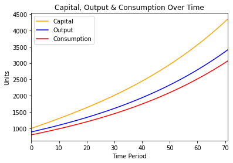

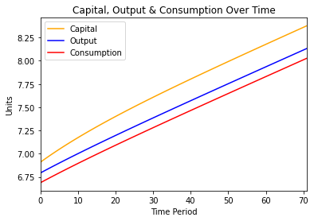

```python
plt.plot(time, df['Capital'], 'orange', label = 'Capital')
plt.plot(time, df['Output'], 'blue', label = 'Output')
plt.plot(time, df['Consumption'], 'red', label = 'Consumption')
plt.title('Capital, Output & Consumption Over Time')
plt.xlabel('Time Period')
plt.ylabel('Units')
plt.xlim(0, len(time)-1)
plt.legend()
plt.show()

plt.plot(time, np.log(df['Capital']), 'orange', label = 'Capital')
plt.plot(time, np.log(df['Output']), 'blue', label = 'Output')
plt.plot(time, np.log(df['Consumption']), 'red', label = 'Consumption')
plt.title('Capital, Output & Consumption Over Time')
plt.xlabel('Time Period')
plt.ylabel('Units')
plt.xlim(0, len(time)-1)
plt.legend()
plt.show()
```

**c)** What are the values of $K_t$, $L_t$, $A_t$ when they first reached the steady-state?

```python
print('Capital when reaching steady state:', '{:,.2f}'.format(K[i-10]))
print('Output when reaching steady state:', '{:,.2f}'.format(Y[i-10]))
print('Consumtion when reaching steady state:', '{:,.2f}'.format(C[i-10]))
print('TFP when reaching steady state:', '{:,.2f}'.format(A[i-10]))
```

```
Capital when reaching steady state: 3,625.22
Output when reaching steady state: 2,844.41
Consumtion when reaching steady state: 2,559.97
TFP when reaching steady state: 2.49
```

### Q4) Quantitative Experiments

Conduct the following quantitative experiments. Start the simulations at the values of capital, labor, and TFP at the steady-state you found in the last part of the previous question. Let the model follow the balanced growth path for 10 periods. Then simulate each of the following scenarios. Please include graphs for the path of $K_t$, $Y_t$, $C_t$ in the level and log scales. Add a different graph of your choosing for each scenario.

**a)** War destroys half of the capital in the US.

The War is going to happen at time 10

```python
#Parameters
s = .1 #savings rate
d = 0.06 #depreciation
alpha = 0.33 #Investingrate
n = n #population growth found earlier
l = 0.01 #LaborInReseach
z = g/l #research productivity


#Starting Levels
K_0 = 1000
L_0 = 500
A_0 = 1.7
Y_0 = ((1-l)**(1-alpha)) *(K_0**(alpha)) *(A_0*L_0)**(1-alpha) #Initial output
I_0 = s*Y_0
C_0 = (1-s)*Y_0
k_s = k_star(s, z, l, n, d, alpha)

#Arrays for While Loop
time = [0]
#Levels
A = np.array([A_0])
L = np.array([L_0])
Y = np.array([Y_0])
K = np.array([K_0])
I = np.array([I_0])
C = np.array([C_0])
#Effiency Units
k = np.array([K_0/(A_0*L_0)])
change_k = np.array([np.nan])
i = 0

epsilon = .01 #How close does it need to get?

while (abs(k[i] - k_s)) > epsilon:
    i += 1
    time = np.append(time, i)



    #Effiency units
    change_k = np.append(change_k,s*((1-l)**(1-alpha))*(k[i-1]**(alpha))-(z*l+n+d)*k[i-1])
    k = np.append(k, k[i-1] + change_k[i])

    #Levels
    L = np.append(L, L[i-1]*(1+n)) #Growth Rate of US
    A = np.append(A, A[i-1]*(1+z*l))
    K = np.append(K, k[i]*A[i]*L[i])
    Y = np.append(Y, ((1-l)**(1-alpha)) *(K[i]**(alpha)) *(A[i]*L[i])**(1-alpha))
    I = np.append(I, s*Y[i])
    C = np.append(C, (1-s)*Y[i])

    if i == 10: #Here is the main thing changed from above at time of 25 we are halfing the amount of capital we have
        K[i] = K[i-1]/2
        k[i] = k[i-1]/2

for i in range(i, i+10):
    i += 1
    time = np.append(time, i)

    #Effiency units
    change_k = np.append(change_k,s*((1-l)**(1-alpha))*(k[i-1]**(alpha))-(z*l+n+d)*k[i-1])
    k = np.append(k, k[i-1] + change_k[i])

    #Levels
    L = np.append(L, L[i-1]*(1+n)) #Growth Rate of US
    A = np.append(A, A[i-1]*(1 + z*l))
    K = np.append(K, k[i]*A[i]*L[i])
    Y = np.append(Y, ((1-l)**(1-alpha)) *(K[i]**(alpha)) *(A[i]*L[i])**(1-alpha))
    I = np.append(I, s*Y[i])
    C = np.append(C, (1-s)*Y[i])


df = pd.DataFrame({'Time':time,
                   'Capital':K,
                   'Output':Y,
                   'Change in Capital':change_k,
                   'Labor':L,
                   'Knowledge':A,
                   'Investment':I,
                   'Consumption':C
                   },
                   columns=['Time',
                            'Capital',
                            'Output',
                            'Change in Capital',
                            'Labor',
                            'Knowledge',
                            'Investment',
                            'Consumption'
                            ]
                    )
print('Reached steady state in',time[i-10],'time periods')
```

```
Reached steady state in 94 time periods
```

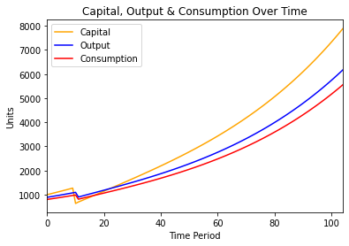

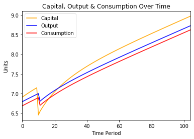

```python
plt.plot(time, df['Capital'], 'orange', label = 'Capital')
plt.plot(time, df['Output'], 'blue', label = 'Output')
plt.plot(time, df['Consumption'], 'red', label = 'Consumption')
plt.title('Capital, Output & Consumption Over Time')
plt.xlabel('Time Period')
plt.ylabel('Units')
plt.xlim(0, len(time)-1)
plt.legend()
plt.show()

plt.plot(time, np.log(df['Capital']), 'orange', label = 'Capital')
plt.plot(time, np.log(df['Output']), 'blue', label = 'Output')
plt.plot(time, np.log(df['Consumption']), 'red', label = 'Consumption')
plt.title('Capital, Output & Consumption Over Time')
plt.xlabel('Time Period')
plt.ylabel('Units')
plt.xlim(0, len(time)-1)
plt.legend()
plt.show()
```

**b)** Millennials suddenly increase their savings rate, doubling the historical average.

```python
#Parameters
s = .1 #savings rate
d = 0.06 #depreciation
alpha = 0.33 #Investingrate
n = n #population growth found earlier
l = 0.01 #LaborInReseach
z = g/l #research productivity


#Starting Levels
K_0 = 1000
L_0 = 500
A_0 = 1.7
Y_0 = ((1-l)**(1-alpha)) *(K_0**(alpha)) *(A_0*L_0)**(1-alpha) #Initial output
I_0 = s*Y_0
C_0 = (1-s)*Y_0
k_s = k_star(s, z, l, n, d, alpha)

#Arrays for While Loop
time = [0]
#Levels
A = np.array([A_0])
L = np.array([L_0])
Y = np.array([Y_0])
K = np.array([K_0])
I = np.array([I_0])
C = np.array([C_0])
#Effiency Units
k = np.array([K_0/(A_0*L_0)])
change_k = np.array([np.nan])
i = 0

epsilon = .01 #How close does it need to get?

while (abs(k[i] - k_s)) > epsilon:
    i += 1
    time = np.append(time, i)

    #Effiency units
    change_k = np.append(change_k,s*((1-l)**(1-alpha))*(k[i-1]**(alpha))-(z*l+n+d)*k[i-1])
    k = np.append(k, k[i-1] + change_k[i])

    #Levels
    L = np.append(L, L[i-1]*(1+n)) #Growth Rate of US
    A = np.append(A, A[i-1]*(1+z*l))
    K = np.append(K, k[i]*A[i]*L[i])
    Y = np.append(Y, ((1-l)**(1-alpha)) *(K[i]**(alpha)) *(A[i]*L[i])**(1-alpha))
    I = np.append(I, s*Y[i])
    C = np.append(C, (1-s)*Y[i])

    if i == 25: # at time of 25 we increase the savings rate by double
        s = s*2
        k_s = k_star(s, z, l, n, d, alpha) # we have a new steady state to stop at because of new savings rate

for i in range(i, i+10):
    i += 1
    time = np.append(time, i)

    #Effiency units
    change_k = np.append(change_k,s*((1-l)**(1-alpha))*(k[i-1]**(alpha))-(z*l+n+d)*k[i-1])
    k = np.append(k, k[i-1] + change_k[i])

    #Levels
    L = np.append(L, L[i-1]*(1+n)) #Growth Rate of US
    A = np.append(A, A[i-1]*(1 + z*l))
    K = np.append(K, k[i]*A[i]*L[i])
    Y = np.append(Y, ((1-l)**(1-alpha)) *(K[i]**(alpha)) *(A[i]*L[i])**(1-alpha))
    I = np.append(I, s*Y[i])
    C = np.append(C, (1-s)*Y[i])


df = pd.DataFrame({'Time':time,
                   'Capital':K,
                   'Output':Y,
                   'Change in Capital':change_k,
                   'Labor':L,
                   'Knowledge':A,
                   'Investment':I,
                   'Consumption':C
                   },
                   columns=['Time',
                            'Capital',
                            'Output',
                            'Change in Capital',
                            'Labor',
                            'Knowledge',
                            'Investment',
                            'Consumption'
                            ]
                    )
print('Reached steady state in',time[i-10],'time periods')
```

```
Reached steady state in 132 time periods
```

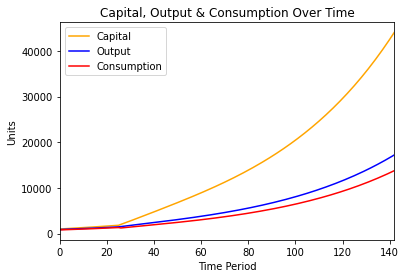

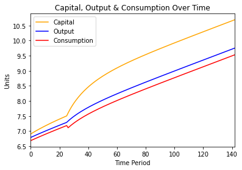

```python
plt.plot(time, df['Capital'], 'orange', label = 'Capital')
plt.plot(time, df['Output'], 'blue', label = 'Output')
plt.plot(time, df['Consumption'], 'red', label = 'Consumption')
plt.title('Capital, Output & Consumption Over Time')
plt.xlabel('Time Period')
plt.ylabel('Units')
plt.xlim(0, len(time)-1)
plt.legend()
plt.show()

plt.plot(time, np.log(df['Capital']), 'orange', label = 'Capital')
plt.plot(time, np.log(df['Output']), 'blue', label = 'Output')
plt.plot(time, np.log(df['Consumption']), 'red', label = 'Consumption')
plt.title('Capital, Output & Consumption Over Time')
plt.xlabel('Time Period')
plt.ylabel('Units')
plt.xlim(0, len(time)-1)
plt.legend()
plt.show()
```

**c)** A peaceful advanced extraterrestrial race gives the US technology that instantly doubles TFP

```python
#Parameters
s = .1 #savings rate
d = 0.06 #depreciation
alpha = 0.33 #Investingrate
n = n #population growth found earlier
l = 0.01 #LaborInReseach
z = g/l #research productivity


#Starting Levels
K_0 = 1000
L_0 = 500
A_0 = 1.7
Y_0 = ((1-l)**(1-alpha)) *(K_0**(alpha)) *(A_0*L_0)**(1-alpha) #Initial output
I_0 = s*Y_0
C_0 = (1-s)*Y_0
k_s = k_star(s, z, l, n, d, alpha)

#Arrays for While Loop
time = [0]
#Levels
A = np.array([A_0])
L = np.array([L_0])
Y = np.array([Y_0])
K = np.array([K_0])
I = np.array([I_0])
C = np.array([C_0])
#Effiency Units
k = np.array([K_0/(A_0*L_0)])
change_k = np.array([np.nan])
i = 0

epsilon = .01 #How close does it need to get?

while (abs(k[i] - k_s)) > epsilon:
    i += 1
    time = np.append(time, i)

    #Effiency units
    change_k = np.append(change_k,s*((1-l)**(1-alpha))*(k[i-1]**(alpha))-(z*l+n+d)*k[i-1])
    k = np.append(k, k[i-1] + change_k[i])

    #Levels
    L = np.append(L, L[i-1]*(1+n)) #Growth Rate of US
    A = np.append(A, A[i-1]*(1+z*l))
    K = np.append(K, k[i]*A[i]*L[i])
    Y = np.append(Y, ((1-l)**(1-alpha)) *(K[i]**(alpha)) *(A[i]*L[i])**(1-alpha))
    I = np.append(I, s*Y[i])
    C = np.append(C, (1-s)*Y[i])

    if i == 25: #we double TFP at time 25
        A[i] = A[i]*2

for i in range(i, i+10):
    i += 1
    time = np.append(time, i)

    #Effiency units
    change_k = np.append(change_k,s*((1-l)**(1-alpha))*(k[i-1]**(alpha))-(z*l+n+d)*k[i-1])
    k = np.append(k, k[i-1] + change_k[i])

    #Levels
    L = np.append(L, L[i-1]*(1+n)) #Growth Rate of US
    A = np.append(A, A[i-1]*(1 + z*l))
    K = np.append(K, k[i]*A[i]*L[i])
    Y = np.append(Y, ((1-l)**(1-alpha)) *(K[i]**(alpha)) *(A[i]*L[i])**(1-alpha))
    I = np.append(I, s*Y[i])
    C = np.append(C, (1-s)*Y[i])


df = pd.DataFrame({'Time':time,
                   'Capital':K,
                   'Output':Y,
                   'Change in Capital':change_k,
                   'Labor':L,
                   'Knowledge':A,
                   'Investment':I,
                   'Consumption':C
                   },
                   columns=['Time',
                            'Capital',
                            'Output',
                            'Change in Capital',
                            'Labor',
                            'Knowledge',
                            'Investment',
                            'Consumption'
                            ]
                    )
print('Reached steady state in',time[i-10],'time periods')
```

```
Reached steady state in 61 time periods
```

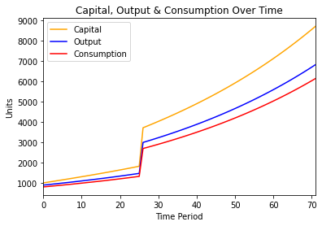

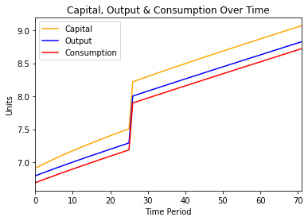

```python
plt.plot(time, df['Capital'], 'orange', label = 'Capital')
plt.plot(time, df['Output'], 'blue', label = 'Output')
plt.plot(time, df['Consumption'], 'red', label = 'Consumption')
plt.title('Capital, Output & Consumption Over Time')
plt.xlabel('Time Period')
plt.ylabel('Units')
plt.xlim(0, len(time)-1)
plt.legend()
plt.show()

plt.plot(time, np.log(df['Capital']), 'orange', label = 'Capital')
plt.plot(time, np.log(df['Output']), 'blue', label = 'Output')
plt.plot(time, np.log(df['Consumption']), 'red', label = 'Consumption')
plt.title('Capital, Output & Consumption Over Time')
plt.xlabel('Time Period')
plt.ylabel('Units')
plt.xlim(0, len(time)-1)
plt.legend()
plt.show()
```

**d)** Poligamy becomes legal and so the growth rate of the popuation triples.

```python
#Parameters
s = .1 #savings rate
d = 0.06 #depreciation
alpha = 0.33 #Investingrate
n = n #population growth found earlier
l = 0.01 #LaborInReseach
z = g/l #research productivity


#Starting Levels
K_0 = 1000
L_0 = 500
A_0 = 1.7
Y_0 = ((1-l)**(1-alpha)) *(K_0**(alpha)) *(A_0*L_0)**(1-alpha) #Initial output
I_0 = s*Y_0
C_0 = (1-s)*Y_0
c_0 = C_0/L_0
y_0 = Y_0/L_0
k_s = k_star(s, z, l, n, d, alpha)

#Arrays for While Loop
time = [0]
#Levels
A = np.array([A_0])
L = np.array([L_0])
Y = np.array([Y_0])
K = np.array([K_0])
I = np.array([I_0])
C = np.array([C_0])
c = np.array([c_0])#Added Conssumption per person
y = np.array([y_0])#Added Output per Person

#Effiency Units
k = np.array([K_0/(A_0*L_0)])
change_k = np.array([np.nan])
i = 0

epsilon = .01 #How close does it need to get?

while (abs(k[i] - k_s)) > epsilon:
    i += 1
    time = np.append(time, i)

    #Effiency units
    change_k = np.append(change_k,s*((1-l)**(1-alpha))*(k[i-1]**(alpha))-(z*l+n+d)*k[i-1])
    k = np.append(k, k[i-1] + change_k[i])

    #Levels
    L = np.append(L, L[i-1]*(1+n)) #Growth Rate of US
    A = np.append(A, A[i-1]*(1+z*l))
    K = np.append(K, k[i]*A[i]*L[i])
    Y = np.append(Y, ((1-l)**(1-alpha)) *(K[i]**(alpha)) *(A[i]*L[i])**(1-alpha))
    I = np.append(I, s*Y[i])
    C = np.append(C, (1-s)*Y[i])
    c = np.append(c, C[i]/L[i]) #Added Conssumption per person
    y = np.append(y, Y[i]/L[i]) #Added Output per Person

    if i == 15: #We triple the population growth rate as the whole country decides to adopt polygomy
        n = n *3
        k_s = k_star(s, z, l, n, d, alpha) #new steady state with with new n value

for i in range(i, i+20):
    i += 1
    time = np.append(time, i)

    #Effiency units
    change_k = np.append(change_k,s*((1-l)**(1-alpha))*(k[i-1]**(alpha))-(z*l+n+d)*k[i-1])
    k = np.append(k, k[i-1] + change_k[i])

    #Levels
    L = np.append(L, L[i-1]*(1+n)) #Growth Rate of US
    A = np.append(A, A[i-1]*(1 + z*l))
    K = np.append(K, k[i]*A[i]*L[i])
    Y = np.append(Y, ((1-l)**(1-alpha)) *(K[i]**(alpha)) *(A[i]*L[i])**(1-alpha))
    I = np.append(I, s*Y[i])
    C = np.append(C, (1-s)*Y[i])
    c = np.append(c, C[i]/L[i])
    y = np.append(y, Y[i]/L[i])


df = pd.DataFrame({'Time':time,
                   'Capital':K,
                   'Output':Y,
                   'Change in Capital':change_k,
                   'Labor':L,
                   'Knowledge':A,
                   'Investment':I,
                   'Consumption':C,
                   'Consumptionperperson':c,
                   'Ouputperperson':y
                   },
                   columns=['Time',
                            'Capital',
                            'Output',
                            'Change in Capital',
                            'Labor',
                            'Knowledge',
                            'Investment',
                            'Consumption',
                            'Consumptionperperson',
                            'Ouputperperson'
                            ]
                    )
print('Reached steady state in',time[i-10],'time periods')
```

```
Reached steady state in 75 time periods
```

[figure not shown]

[figure not shown]

```python
plt.plot(time, df['Capital'], 'orange', label = 'Capital')
plt.plot(time, df['Output'], 'blue', label = 'Output')
plt.plot(time, df['Consumption'], 'red', label = 'Consumption')
plt.title('Capital, Output & Consumption Over Time')
plt.xlabel('Time Period')
plt.ylabel('Units')
plt.xlim(0, len(time)-1)
plt.legend()
plt.show()

plt.plot(time, np.log(df['Capital']), 'orange', label = 'Capital')
plt.plot(time, np.log(df['Output']), 'blue', label = 'Output')
plt.plot(time, np.log(df['Consumption']), 'red', label = 'Consumption')
plt.title('Capital, Output & Consumption Over Time')
plt.xlabel('Time Period')
plt.ylabel('Units')
plt.xlim(0, len(time)-1)
plt.legend()
plt.show()
```

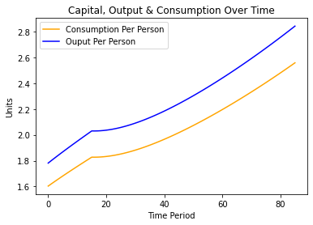

```python
plt.plot(time, df['Consumptionperperson'], 'orange', label = 'Consumption Per Person')
plt.plot(time, df['Ouputperperson'], 'blue', label = 'Ouput Per Person')
plt.title('Capital, Output & Consumption Over Time')
plt.xlabel('Time Period')
plt.ylabel('Units')
plt.legend()
plt.show()
```